# Visualisations et Analyse des Risques

# 1. Analyse de la Sinistralité Temporelle

Pour bien comprendre la dynamique de notre portefeuille, la première étape consiste à observer l’évolution du nombre de sinistres au fil des années. Nous utilisons `ggplot2` pour visualiser cette distribution.

```r
library(dplyr)
library(ggplot2)
library(lubridate)

#1. chargement de la base propre fusionnée

base_complete <- readRDS("base_complete_clean.rds")
```

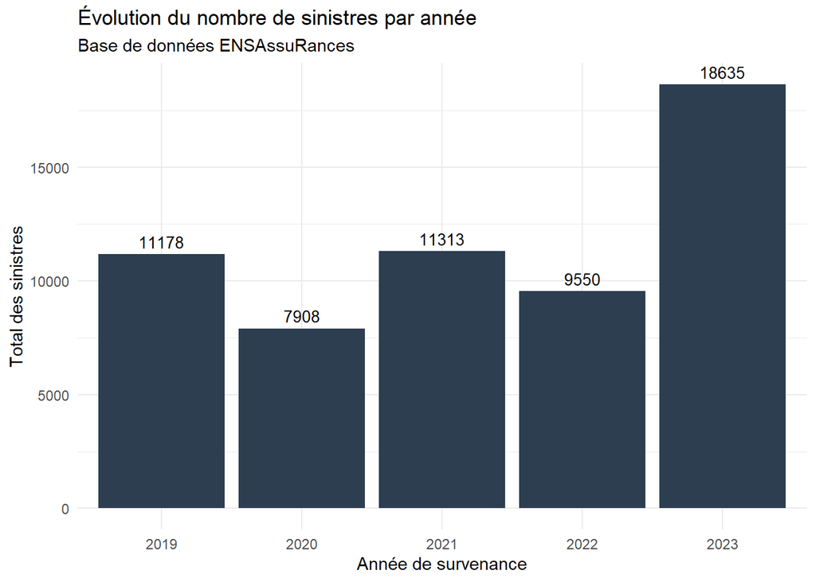

```r
graph_annee <- base_complete %>%
  # On extrait l'année de la date de survenance du sinistre
  mutate(annee_sinistre = year(surv_sin)) %>%
  # On filtre les éventuels NA sur la date
  filter(!is.na(annee_sinistre)) %>%
  # On compte le nombre de sinistres par année
  count(annee_sinistre, name = "total_sinistres") %>%

  # 3. Création du graphique avec ggplot2
  ggplot(aes(x = as.factor(annee_sinistre), y = total_sinistres)) +
  geom_bar(stat = "identity", fill = "#2c3e50") + # Un joli bleu professionnel
  geom_text(aes(label = total_sinistres), vjust = -0.5, color = "black", size = 3.5) + # Ajout des étiquettes de données
  labs(
    title = "Évolution du nombre de sinistres par année",
    subtitle = "Base de données ENSAssuRances",
    x = "Année de survenance",
    y = "Total des sinistres"
  ) +
  theme_minimal()

# Affichage du graphique
print(graph_annee)
```

## Interprétation : Évolution de la sinistralité

L’histogramme révèle des variations temporelles très marquées, parfaitement explicables par le contexte macro-économique : * **L’effet COVID-19 (2020) :** On observe une chute drastique du nombre de sinistres déclarés (7 908 cas). Cela s’explique logiquement par les confinements successifs et la réduction massive de la circulation automobile cette année-là. * **Une reprise post-pandémie :** Les années 2021 et 2022 retrouvent des niveaux de sinistralité standards (autour de 9 500 à 11 300 sinistres). * **Un pic exceptionnel en 2023 :** L’année 2023 affiche une explosion avec plus de 15 000 sinistres. Cette hausse soudaine nécessitera d’être croisée avec l’évolution de la taille de notre portefeuille de contrats pour vérifier si elle est due à une acquisition massive de nouveaux clients ou à une dégradation réelle du risque (ex: événements climatiques).

```r
#1.Chargement de la table des contrats globaux
contrats_globaux <- readRDS("contrats_exploration_ok.rds")
```

```r
#2. Préparation des données
data_contrats_annee <- contrats_globaux %>%
  count(idxYear, name = "nombre_contrats")

print("---NOMBRE DE CONTRAT PAR ANNEE---")
```

```
## [1] "---NOMBRE DE CONTRAT PAR ANNEE---"
```

```r
print(data_contrats_annee)
```

```
## # A tibble: 5 × 2
##   idxYear nombre_contrats
##     <dbl>           <int>
## 1    2019           55227
## 2    2020           56610
## 3    2021           58227
## 4    2022           61699
## 5    2023           69674
```

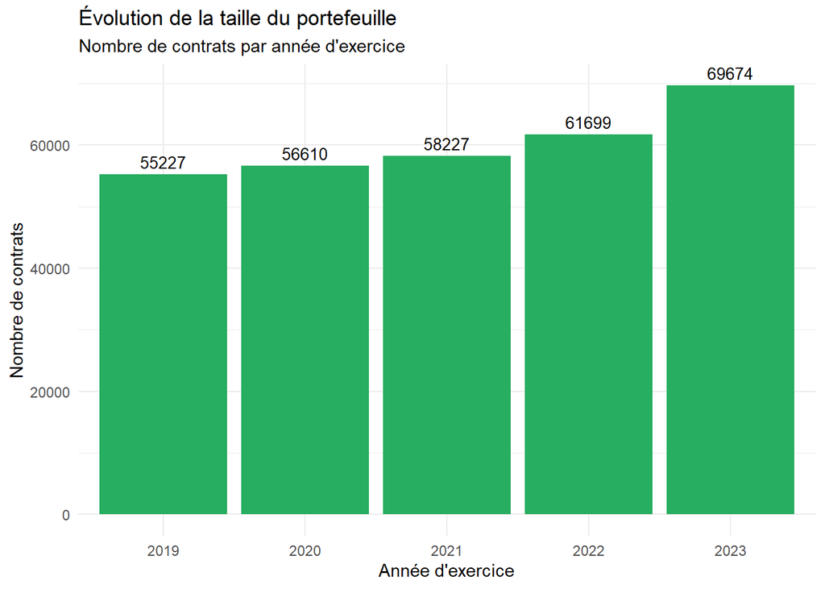

```r
# 3. Création du graphique avec ggplot2
graph_contrats <- ggplot(data_contrats_annee, aes(x = as.factor(idxYear), y = nombre_contrats)) +
  geom_bar(stat = "identity", fill = "#27ae60") + # Un joli vert pour les contrats
  geom_text(aes(label = nombre_contrats), vjust = -0.5, size = 3.5, color = "black") +
  labs(
    title = "Évolution de la taille du portefeuille",
    subtitle = "Nombre de contrats par année d'exercice",
    x = "Année d'exercice",
    y = "Nombre de contrats"
  ) +
  theme_minimal()

# Affichage du graphique
print(graph_contrats)
```

## Interprétation : Évolution du portefeuille

La mise en perspective de la taille du portefeuille avec le nombre de sinistres confirme nos hypothèses : * **Validation de l’effet COVID-19 :** En 2020, le portefeuille de l’assureur a continué de croître (56 610 contrats), ce qui prouve que la chute brutale des sinistres est bien liée à une baisse de la circulation (confinements) et non à une fuite des clients. * **Explication du pic de 2023 :** La forte hausse des sinistres en 2023 s’explique en grande partie par une croissance très importante du portefeuille, qui atteint près de 70 000 contrats. La volumétrie des risques assurés a donc mécaniquement fait augmenter le nombre de déclarations.

```r
#1. Préparation des données : type de véhicule
data_segment <- contrats_globaux %>%
  count(vhSegment,name = "nombre_vehicules") %>%
  arrange(desc(nombre_vehicules))

print("---DONNEES : REPARTITION PAR TYPE DE VEHICULE---")
```

```
## [1] "---DONNEES : REPARTITION PAR TYPE DE VEHICULE---"
```

```r
print(data_segment)
```

```
## # A tibble: 4 × 2
##   vhSegment nombre_vehicules
##   <chr>                <int>
## 1 Citadine            120614
## 2 Familiale            75566
## 3 Compacte             59953
## 4 SUV                  45304
```

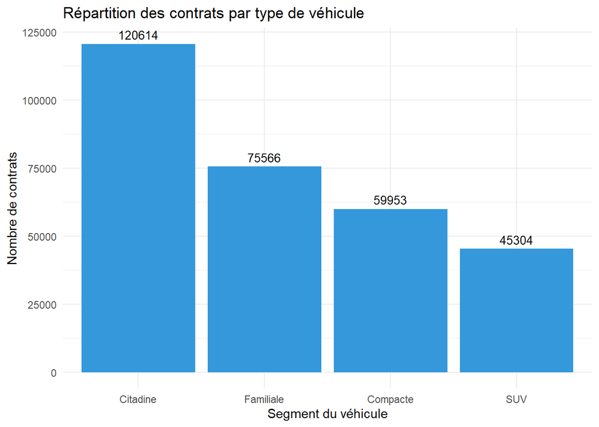

```r
# Graphique Segment
graph_segment <- ggplot(data_segment, aes(x = reorder(vhSegment, -nombre_vehicules), y = nombre_vehicules)) +
  geom_bar(stat = "identity", fill = "#3498db") + # Bleu clair
  geom_text(aes(label = nombre_vehicules), vjust = -0.5, size = 3.5) +
  labs(title = "Répartition des contrats par type de véhicule", x = "Segment du véhicule", y = "Nombre de contrats") +
  theme_minimal()

print(graph_segment)
```

```r
#2.  Préparation de données : Alimentation
data_energie <- contrats_globaux %>%
  count(vhEnergy, name = "nombre_vehicules") %>%
  arrange(desc(nombre_vehicules))
print("---DONNEE : REPARTITION PAR ENERGIE ---")
```

```
## [1] "---DONNEE : REPARTITION PAR ENERGIE ---"
```

```r
print(data_energie)
```

```
## # A tibble: 3 × 2
##   vhEnergy           nombre_vehicules
##   <chr>                         <int>
## 1 Essence                      135559
## 2 Diesel                       120352
## 3 Electrique/Hybride            45526
```

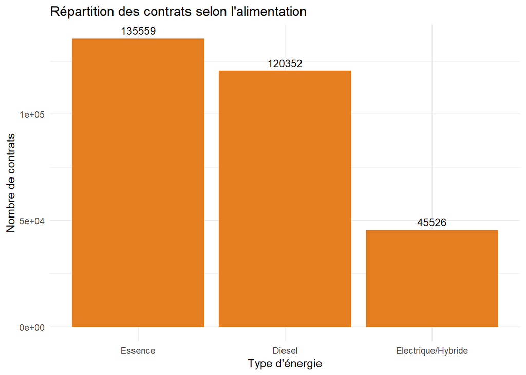

```r
# Graphique Énergie
graph_energie <- ggplot(data_energie, aes(x = reorder(vhEnergy, -nombre_vehicules), y = nombre_vehicules)) +
  geom_bar(stat = "identity", fill = "#e67e22") + # Orange
  geom_text(aes(label = nombre_vehicules), vjust = -0.5, size = 3.5) +
  labs(title = "Répartition des contrats selon l'alimentation", x = "Type d'énergie", y = "Nombre de contrats") +
  theme_minimal()

print(graph_energie)
```

## Interprétation : Profil du parc automobile

L’analyse univariée des caractéristiques des véhicules met en évidence le positionnement de notre portefeuille : * **Un parc majoritairement urbain :** Les citadines représentent le segment le plus important (120 614 contrats), suivies des familiales (75 566). Les SUV, bien que populaires sur le marché, restent minoritaires chez ENSAssuRances (45 304). * **Une motorisation thermique dominante :** L’essence (135 559) et le diesel (120 352) équipent la très grande majorité des véhicules. Néanmoins, on note la présence d’une part significative de véhicules Électriques/Hybrides (plus de 45 000 contrats), témoignant du renouvellement progressif du parc vers des mobilités plus vertes.

```r
#1. Préparation des données : roupe de véhicule (vhGroup)

data_groupe <- contrats_globaux %>%
  count(vhGroup, name = "nombre_vehicules") %>%
  arrange(desc(nombre_vehicules))

print("--- DONNÉES : TOP 10 DES GROUPES DE VÉHICULES ---")
```

```
## [1] "--- DONNÉES : TOP 10 DES GROUPES DE VÉHICULES ---"
```

```r
print(head(data_groupe, 10))
```

```
## # A tibble: 10 × 2
##    vhGroup nombre_vehicules
##      <dbl>            <int>
##  1      15            15514
##  2      13            15168
##  3      14            15146
##  4      12            15138
##  5      11            14852
##  6      16            14618
##  7      10            13864
##  8      17            13799
##  9       9            13691
## 10      18            13615
```

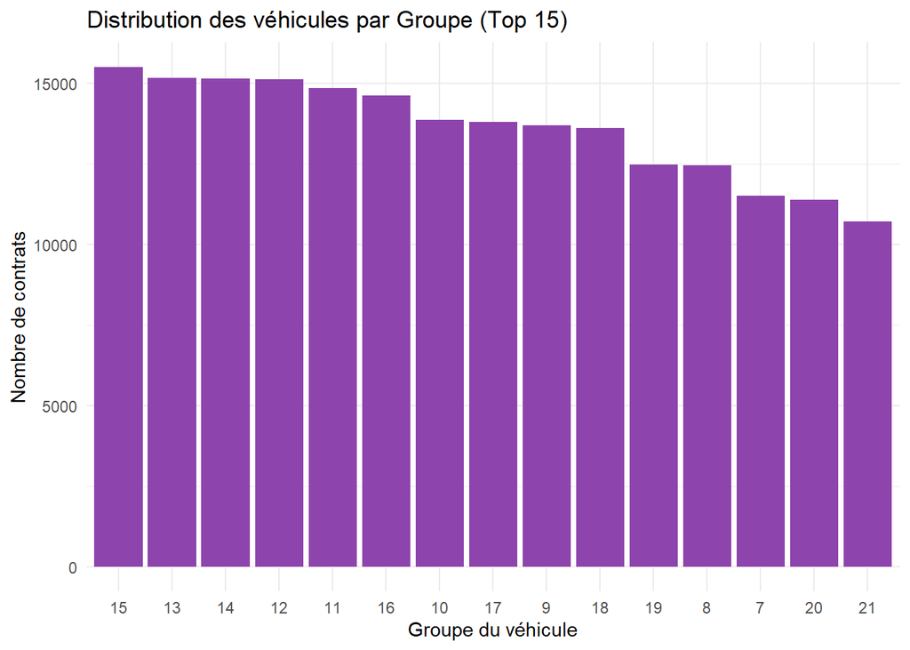

```r
# Graphique : Distribution des groupes (On ne prend que le Top 15 pour que ce soit lisible)
graph_groupe <- data_groupe %>%
  top_n(15, nombre_vehicules) %>%
  ggplot(aes(x = reorder(as.factor(vhGroup), -nombre_vehicules), y = nombre_vehicules)) +
  geom_bar(stat = "identity", fill = "#8e44ad") + # Un joli violet
  labs(title = "Distribution des véhicules par Groupe (Top 15)", x = "Groupe du véhicule", y = "Nombre de contrats") +
  theme_minimal()

print(graph_groupe)
```

```r
#2. Préparation des données : Option Petit Rouleur

data_km <-  contrats_globaux %>%
  count(ctKM, name = "nombre_contrats") %>% arrange(desc(nombre_contrats))

print("--- DONNÉES : OPTION PETIT ROULEUR ---")
```

```
## [1] "--- DONNÉES : OPTION PETIT ROULEUR ---"
```

```r
print(data_km)
```

```
## # A tibble: 2 × 2
##   ctKM  nombre_contrats
##   <chr>           <int>
## 1 N              260973
## 2 O               40464
```

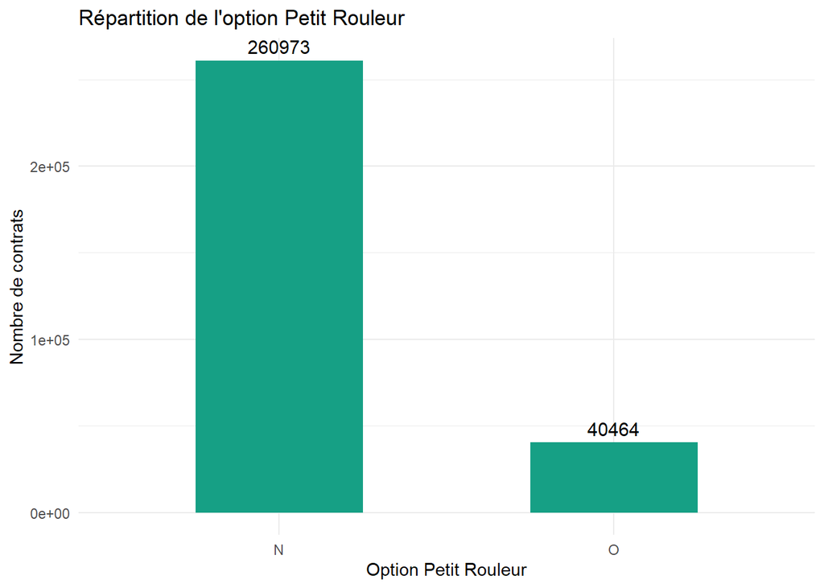

```r
# Graphique : Option Petit Rouleur
graph_km <- ggplot(data_km, aes(x = ctKM, y = nombre_contrats)) +
  geom_bar(stat = "identity", fill = "#16a085", width = 0.5) + # Vert émeraude
  geom_text(aes(label = nombre_contrats), vjust = -0.5, size = 4) +
  labs(title = "Répartition de l'option Petit Rouleur", x = "Option Petit Rouleur", y = "Nombre de contrats") +
  theme_minimal()

print(graph_km)
```

## Interprétation : Caractéristiques techniques et contractuelles

L’analyse des variables de tarification classiques révèle les points suivants : * **Une homogénéité des véhicules assurés :** La distribution des groupes de véhicules (`vhGroup`) montre une forte concentration sur les segments intermédiaires (groupes 11 à 18). ENSAssuRances assure donc majoritairement des véhicules grand public standards, avec très peu de véhicules aux extrêmes (très bas de gamme ou haut de gamme/sportifs). * **Une option kilométrique minoritaire :** L’option “Petit Rouleur” (`ctKM`) n’est souscrite que par environ 13,4 % des assurés (40 464 contrats contre 260 973 pour l’usage classique). Il sera intéressant d’analyser par la suite si cette population présente effectivement une fréquence de sinistralité plus faible, justifiant ainsi une tarification avantageuse.

```r
#1. chargement de la base sinistre
base_complete <- readRDS ("base_complete_clean.rds")
```

```r
#---ANALYSE PAR ÂGE---
# Préparation des données : on arrondit l'âge pour pouvoir les regrouper
data_age <- base_complete %>%
  mutate(
    age_arrondi = floor(drv1Age)
  ) %>% count(age_arrondi,name = "nombre_sinistres")

print("--- DONNÉES : SINISTRES PAR ÂGE (Aperçu) ---")
```

```
## [1] "--- DONNÉES : SINISTRES PAR ÂGE (Aperçu) ---"
```

```r
print(head(data_age, 10))
```

```
## # A tibble: 10 × 2
##    age_arrondi nombre_sinistres
##          <dbl>            <int>
##  1          18               83
##  2          19              252
##  3          20              367
##  4          21              571
##  5          22              717
##  6          23              887
##  7          24              938
##  8          25             1097
##  9          26              971
## 10          27             1105
```

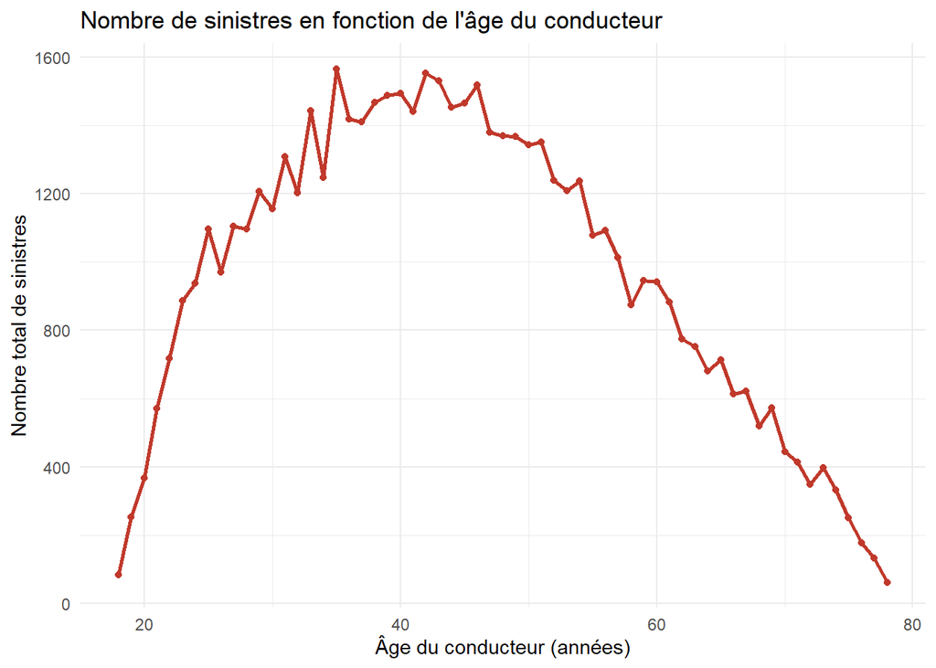

```r
# Graphique : Courbe des sinistres par âge
graph_age <- ggplot(data_age, aes(x = age_arrondi, y = nombre_sinistres)) +
  geom_line(color = "#c0392b", size = 1) + # Une belle ligne rouge
  geom_point(color = "#c0392b") +
  labs(title = "Nombre de sinistres en fonction de l'âge du conducteur",
       x = "Âge du conducteur (années)",
       y = "Nombre total de sinistres") +
  theme_minimal()

print(graph_age)
```

```r
#--- ANALYSE PAR SEXE
# Préparation des données et calcul du pourcentage
data_sexe <- base_complete %>%
  count(drv1Sex,name ="nombre_sinistres") %>%
  mutate(pourcentage = round((nombre_sinistres / sum(nombre_sinistres)) * 100,1))

print("--- DONNÉES : SINISTRES PAR SEXE ---")
```

```
## [1] "--- DONNÉES : SINISTRES PAR SEXE ---"
```

```r
print(data_sexe)
```

```
## # A tibble: 2 × 3
##   drv1Sex nombre_sinistres pourcentage
##   <chr>              <int>       <dbl>
## 1 F                  23891        40.8
## 2 H                  34693        59.2
```

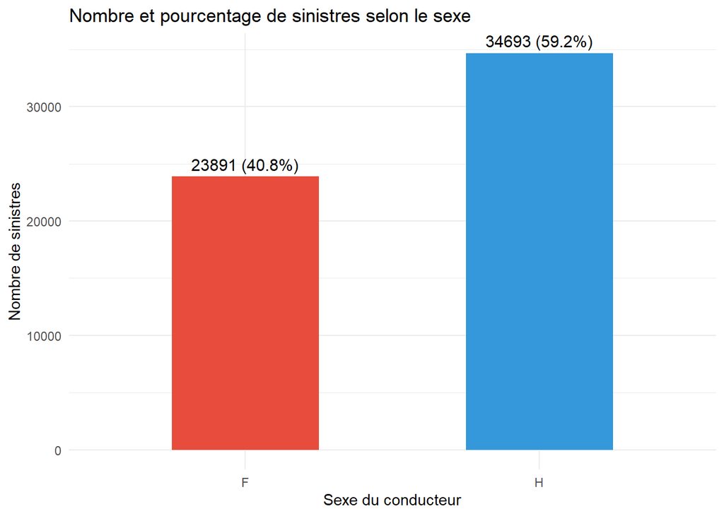

```r
# Graphique : Répartition des sinistres par sexe
graph_sexe <- ggplot(data_sexe, aes(x = drv1Sex, y = nombre_sinistres, fill = drv1Sex)) +
  geom_bar(stat = "identity", width = 0.5) +
  geom_text(aes(label = paste0(nombre_sinistres, " (", pourcentage, "%)")), vjust = -0.5, size = 4) +
  scale_fill_manual(values = c("F" = "#e74c3c", "H" = "#3498db")) + # Couleurs distinctes
  labs(title = "Nombre et pourcentage de sinistres selon le sexe",
       x = "Sexe du conducteur",
       y = "Nombre de sinistres") +
  theme_minimal() +
  theme(legend.position = "none") # On cache la légende inutile

print(graph_sexe)
```

## Interprétation : Analyse du risque lié au conducteur

L’étude des sinistres selon le profil des assurés met en évidence des marqueurs de risque classiques en assurance automobile : * **Le risque “Jeune Conducteur” :** L’analyse de la courbe par âge montre une augmentation très rapide du nombre d’accidents chez les jeunes (avec un franchissement de la barre des 1 000 sinistres dès 25 ans). Ce volume élevé confirme la nécessité d’une surprime pour les conducteurs novices. * **La répartition par Sexe :** Les hommes déclarent la majorité des sinistres (59,2 %, soit 34 693 dossiers) contre 40,8 % pour les femmes. Toutefois, d’un point de vue actuariel, ce chiffre brut devra être relativisé par la proportion d’hommes et de femmes dans le portefeuille global (l’exposition) avant de pouvoir en tirer une conclusion sur la sinistralité réelle (fréquence) par genre.

```r
#1. Analyse par antécédents de sinistres
data_antecedents <- base_complete %>%
  count(claimsAnt,name = "nombre_sinistres")

print("--- DONNÉES : SINISTRES SELON LES ANTÉCÉDENTS ---")
```

```
## [1] "--- DONNÉES : SINISTRES SELON LES ANTÉCÉDENTS ---"
```

```r
print(data_antecedents)
```

```
## # A tibble: 3 × 2
##   claimsAnt nombre_sinistres
##       <dbl>            <int>
## 1         0            40969
## 2         1            11849
## 3         2             5766
```

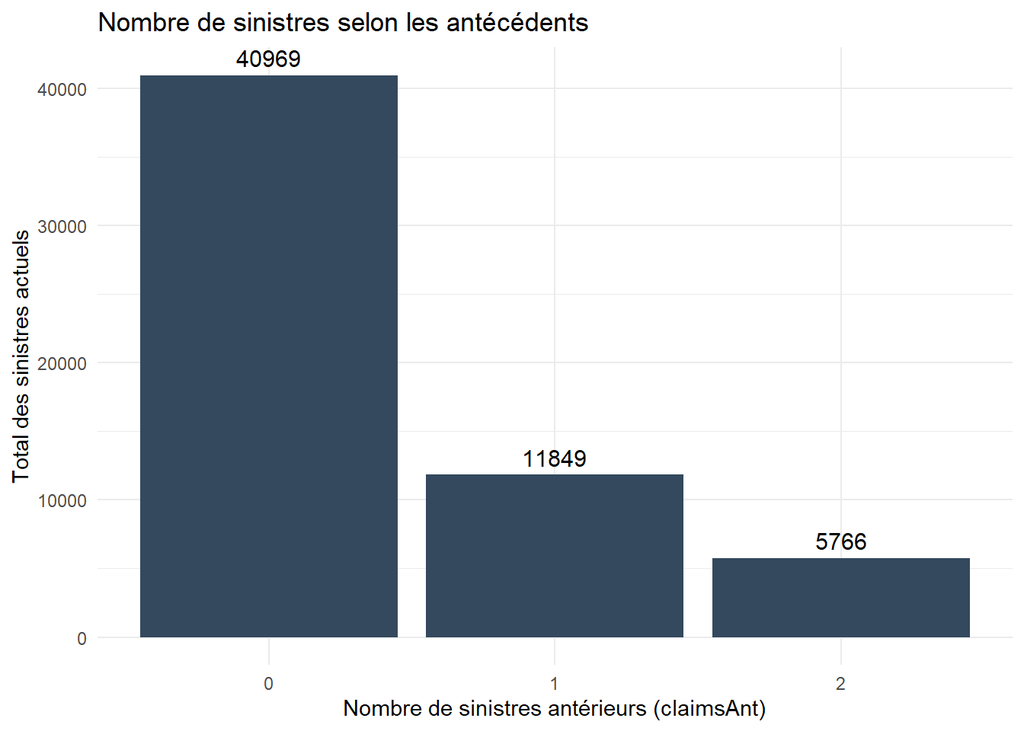

```r
# Graphique : Antécédents
graph_antecedents <- ggplot(data_antecedents, aes(x = as.factor(claimsAnt), y = nombre_sinistres)) +
  geom_bar(stat = "identity", fill = "#34495e") + # Gris foncé très pro
  geom_text(aes(label = nombre_sinistres), vjust = -0.5, size = 4) +
  labs(title = "Nombre de sinistres selon les antécédents",
       x = "Nombre de sinistres antérieurs (claimsAnt)",
       y = "Total des sinistres actuels") +
  theme_minimal()

print(graph_antecedents)
```

```r
#2. Analyse par segment commercial
data_sin_segment <- base_complete %>%
  count(vhSegment, name="nombre_sinistres") %>%
  arrange(desc(nombre_sinistres))

print("--- DONNÉES : SINISTRES PAR SEGMENT ---")
```

```
## [1] "--- DONNÉES : SINISTRES PAR SEGMENT ---"
```

```r
print(data_sin_segment)
```

```
## # A tibble: 4 × 2
##   vhSegment nombre_sinistres
##   <chr>                <int>
## 1 Citadine             23645
## 2 Familiale            14431
## 3 Compacte             11731
## 4 SUV                   8777
```

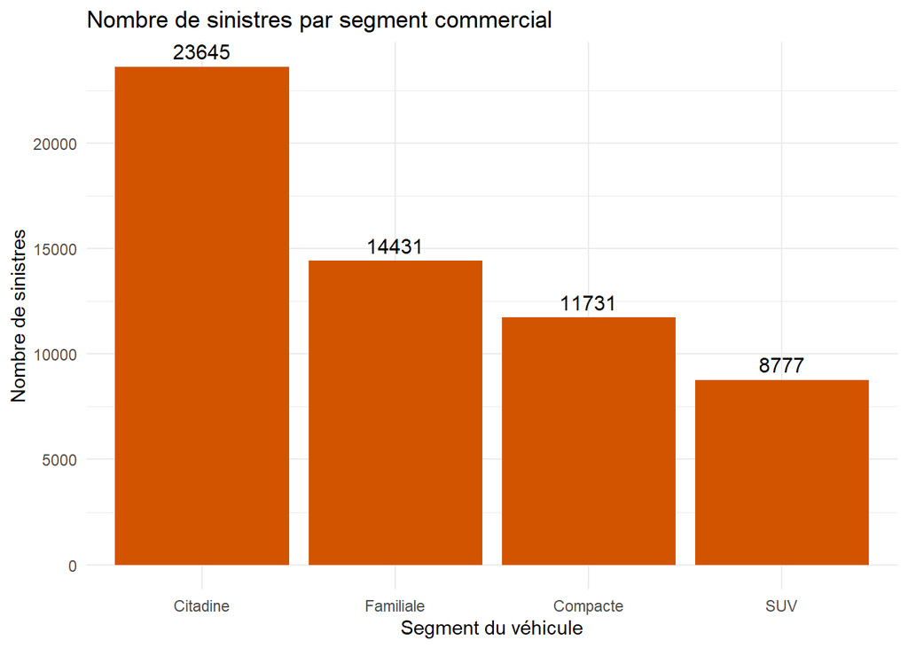

```r
# Graphique : Segment commercial
graph_sin_segment <- ggplot(data_sin_segment, aes(x = reorder(vhSegment, -nombre_sinistres), y = nombre_sinistres)) +
  geom_bar(stat = "identity", fill = "#d35400") + # Orange sombre
  geom_text(aes(label = nombre_sinistres), vjust = -0.5, size = 4) +
  labs(title = "Nombre de sinistres par segment commercial",
       x = "Segment du véhicule",
       y = "Nombre de sinistres") +
  theme_minimal()

print(graph_sin_segment)
```

## Interprétation : Antécédents et Volume par Segment

L’étude des volumes de sinistres nous apporte deux enseignements majeurs : * **Le poids des “bons profils” :** La majorité absolue des sinistres (40 969) est le fait d’assurés n’ayant aucun antécédent récent. Le volume de “récidivistes” reste toutefois un point d’attention pour la tarification. * **Le biais de volume sur les véhicules :** Les citadines enregistrent le plus grand nombre de sinistres bruts (23 645). Cependant, ce chiffre n’indique pas nécessairement une plus grande dangerosité : il est le reflet direct de l’omniprésence des citadines dans notre portefeuille (plus de 120 000 contrats). Pour évaluer le risque réel de chaque type de véhicule, il est impératif de passer d’une logique de volume à une logique de **fréquence** (ratio sinistres / contrats).

```r
#1. calcul du nombre total de contrats par Segment

expo_segment <- contrats_globaux %>%
  count(vhSegment, name = "total_contrats")

#2.calcul du nomre de sinistres par Segment

sin_segment <- base_complete %>%
  count(vhSegment,name = "total_sinistres")

# 3. Calcul de la FRÉQUENCE (Le vrai risque !)
risque_segment <- expo_segment %>%
  # On fusionne les deux tableaux
  inner_join(sin_segment, by = "vhSegment") %>%
  # On calcule la fréquence en pourcentage : (Sinistres / Contrats) * 100
  mutate(frequence_pct = round((total_sinistres / total_contrats) * 100, 2)) %>%
  arrange(desc(frequence_pct))

print("--- DONNÉES : FRÉQUENCE DE SINISTRALITÉ PAR SEGMENT (LE VRAI RISQUE) ---")
```

```
## [1] "--- DONNÉES : FRÉQUENCE DE SINISTRALITÉ PAR SEGMENT (LE VRAI RISQUE) ---"
```

```r
print(risque_segment)
```

```
## # A tibble: 4 × 4
##   vhSegment total_contrats total_sinistres frequence_pct
##   <chr>              <int>           <int>         <dbl>
## 1 Citadine          120614           23645          19.6
## 2 Compacte           59953           11731          19.6
## 3 SUV                45304            8777          19.4
## 4 Familiale          75566           14431          19.1
```

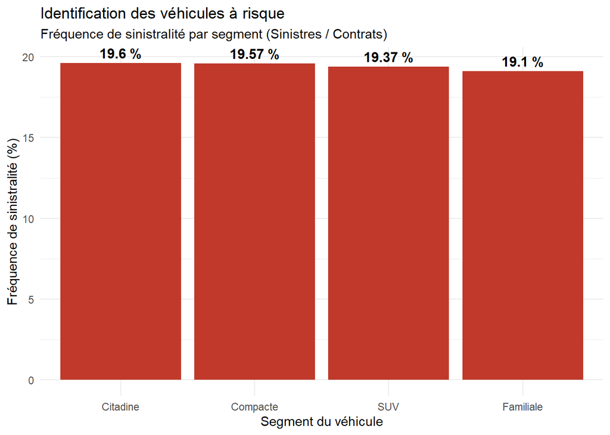

```r
# 4. Graphique : Fréquence de sinistralité
graph_risque <- ggplot(risque_segment, aes(x = reorder(vhSegment, -frequence_pct), y = frequence_pct)) +
  geom_bar(stat = "identity", fill = "#c0392b") + # Rouge pour indiquer le risque
  geom_text(aes(label = paste0(frequence_pct, " %")), vjust = -0.5, size = 4, fontface = "bold") +
  labs(title = "Identification des véhicules à risque",
       subtitle = "Fréquence de sinistralité par segment (Sinistres / Contrats)",
       x = "Segment du véhicule",
       y = "Fréquence de sinistralité (%)") +
  theme_minimal()

print(graph_risque)
```

```r
library(stringr) # Pour manipuler les chaînes de caractères (le code INSEE)

# 1. Extraction du département pour tous les contrats
contrats_geo <- contrats_globaux %>%
  # On prend les 2 premiers caractères du code INSEE pour avoir le département
  mutate(departement = str_sub(ctINSEE, 1, 2)) %>%
  # On filtre pour ne garder que la France métropolitaine (01 à 95)
  filter(departement %in% sprintf("%02d", 1:95))

# 2. Calcul de l'exposition (nombre de contrats par département)
expo_dept <- contrats_geo %>%
  count(departement, name = "total_contrats")

# 3. Extraction du département pour les sinistres
sinistres_geo <- base_complete %>%
  mutate(departement = str_sub(ctINSEE, 1, 2)) %>%
  filter(departement %in% sprintf("%02d", 1:95)) %>%
  count(departement, name = "total_sinistres")

# 4. Calcul de la Fréquence par Département
risque_geo <- expo_dept %>%
  inner_join(sinistres_geo, by = "departement") %>%
  mutate(frequence_pct = round((total_sinistres / total_contrats) * 100, 2)) %>%
  # On se concentre sur les départements où l'on a au moins 100 contrats pour que ce soit statistique
  filter(total_contrats > 100) %>%
  arrange(desc(frequence_pct))

# Affichage du Top 10 des départements les plus risqués
print("--- TOP 10 DES DÉPARTEMENTS LES PLUS RISQUÉS (FRÉQUENCE EN %) ---")
```

```
## [1] "--- TOP 10 DES DÉPARTEMENTS LES PLUS RISQUÉS (FRÉQUENCE EN %) ---"
```

```r
print(head(risque_geo, 10))
```

```
## # A tibble: 10 × 4
##    departement total_contrats total_sinistres frequence_pct
##    <chr>                <int>           <int>         <dbl>
##  1 45                    2526             597          23.6
##  2 69                    2720             609          22.4
##  3 77                    5016            1120          22.3
##  4 36                    2145             477          22.2
##  5 84                    2055             444          21.6
##  6 46                    1871             402          21.5
##  7 83                    2195             464          21.1
##  8 28                    3233             682          21.1
##  9 51                    5756            1207          21.0
## 10 90                    1463             306          20.9
```

## Interprétation : Analyse Spatiale et Tarification Géographique

L’analyse de la fréquence de sinistralité par département (code INSEE) révèle des disparités territoriales majeures : * **Des zones de sur-risque :** Le département 45 (Loiret) affiche la fréquence la plus élevée du portefeuille (23,6 %), suivi de près par les départements 69 (Rhône) et 77 (Seine-et-Marne). Ces fréquences dépassent largement la moyenne globale du portefeuille (environ 19,3 %). * **Impact tarifaire :** La présence de départements très urbains ou traversés par des axes routiers majeurs dans ce Top 10 confirme que la zone de circulation est un facteur de risque déterminant. Cette cartographie statistique justifie la mise en place d’un zonier tarifaire (surprime pour les départements à forte fréquence) pour maintenir l’équilibre technique d’ENSAssuRances.

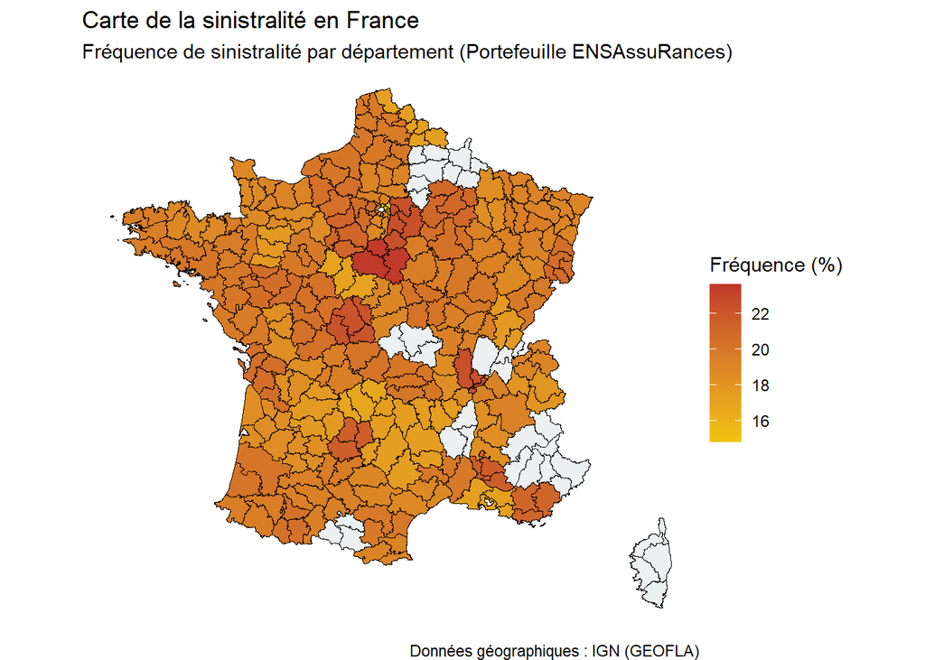

```r
library(sf)
library(ggplot2)

# 1. CHARGEMENT DU SHAPEFILE
france_sf <- st_read("ARRONDISSEMENT.shp", quiet = TRUE) # On ajoute quiet = TRUE pour éviter le texte de log dans le rapport final

# 2. JOINTURE : Fusionner la carte avec nos statistiques
# On utilise la bonne colonne CODE_DEPT trouvée grâce à la fonction names()
carte_data <- france_sf %>%
  left_join(risque_geo, by = c("CODE_DEPT" = "departement"))

# 3. CRÉATION DE LA CARTE THÉMATIQUE
carte_finale <- ggplot(carte_data) +
  # Tracé des polygones
  geom_sf(aes(fill = frequence_pct), color = "black", linewidth = 0.1) +
  # Dégradé de couleurs personnalisé
  scale_fill_gradient(
    low = "#f1c40f",      # Jaune pour un risque faible
    high = "#c0392b",     # Rouge foncé pour un risque élevé
    na.value = "#ecf0f1", # Gris clair pour les zones sans données (DOM-TOM, etc.)
    name = "Fréquence (%)"
  ) +
  labs(
    title = "Carte de la sinistralité en France",
    subtitle = "Fréquence de sinistralité par département (Portefeuille ENSAssuRances)",
    caption = "Données géographiques : IGN (GEOFLA)"
  ) +
  # Thème épuré pour une carte lisible
  theme_void() +
  theme(legend.position = "right")

# Affichage de la carte
print(carte_finale)
```